# Introduction to Functions

Guillaume Abgrall

2019-02-13

#### Nice table printing

```r
library(knitr)
library(kableExtra)
options(knitr.table.format = "html")
dt <- mtcars[1:5, 1:6]
dt %>%
  kable() %>%
  kable_styling(bootstrap_options = c("striped", "hover", "condensed"), full_width = F, position = "left", , font_size = 10) %>%
  row_spec(0, bold = T, color = "white", background = "#3f7689")
```

|  | mpg | cyl | disp | hp | drat | wt |
| --- | --- | --- | --- | --- | --- | --- |
| Mazda RX4 | 21.0 | 6 | 160 | 110 | 3.90 | 2.620 |
| Mazda RX4 Wag | 21.0 | 6 | 160 | 110 | 3.90 | 2.875 |
| Datsun 710 | 22.8 | 4 | 108 | 93 | 3.85 | 2.320 |
| Hornet 4 Drive | 21.4 | 6 | 258 | 110 | 3.08 | 3.215 |
| Hornet Sportabout | 18.7 | 8 | 360 | 175 | 3.15 | 3.440 |

```r
#install.packages("kableExtra")
```

#### XML table try

```r
library(xml2)

k_xml <- kable(mtcars[1:5, 1:6]) %>%
  kable_as_xml()

k_xml
```

```
## {xml_node}
## <table>
## [1] <thead>\n  <tr>\n   <th style="text-align:left;">   </th>\n   <th st ...
## [2] <tbody>\n  <tr>\n   <td style="text-align:left;"> Mazda RX4 </td>\n  ...
```

```r
#k_xml %>%
#  xml_child(2) %>%  # Go to <tbody> tag
#  xml_find_all("//tr/td[2]") %>%  # Find all 2nd td of tr rows
#  xml_set_attr("class", "alter_table") # Add an attribute

#xml_as_kable(k_xml)
```

## Function principles

#### Function documentation

Before even thinking of using an R function, you should clarify which arguments it expects. All the relevant details such as a description, usage, and arguments can be found in the documentation. To consult the documentation on the `sample()` function, for example, you can use one of following R commands:

> `help(sample)`  
> `?sample`

If you execute these commands in the console of the DataCamp interface, you’ll be redirected to www.rdocumentation.org.

A quick hack to see the arguments of the `sample()` function is the `args()` function. Try it out in the console:

> `args(sample)`

In the next exercises, you’ll be learning how to use the `mean()` function with increasing complexity. The first thing you’ll have to do is get acquainted with the `mean()` function.

```r
# Consult the documentation on the mean() function
help(mean)
```

```
## starting httpd help server ... done
```

```r
# Inspect the arguments of the mean() function
args(mean)
```

```
## function (x, ...)
## NULL
```

#### Use a function

The documentation on the `mean()` function gives us quite some information:

+The mean() function computes the arithmetic mean.  
+The most general method takes multiple arguments: x and ….  
+The x argument should be a vector containing numeric, logical or time-related information.

Remember that R can match arguments both by position and by name. Can you still remember the difference? You’ll find out in this exercise!

Once more, you’ll be working with the view counts of your social network profiles for the past 7 days. These are stored in the linkedin and facebook vectors and have already been defined in the editor on the right.

```r
# The linkedin and facebook vectors have already been created for you
linkedin <- c(16, 9, 13, 5, 2, 17, 14)
facebook <- c(17, 7, 5, 16, 8, 13, 14)

# Calculate average number of views
avg_li=mean(linkedin, na.rm = TRUE)
avg_fb=mean(facebook)

# Inspect avg_li and avg_fb
avg_li
```

```
## [1] 10.85714
```

```r
avg_fb
```

```
## [1] 11.42857
```

#### Use a function (2)

Check the documentation on the mean() function again:

> `?mean`

The Usage section of the documentation includes two versions of the mean() function. The first usage,

> `mean(x, ...)`

is the most general usage of the mean function. The ‘Default S3 method’, however, is:

> `mean(x, trim = 0, na.rm = FALSE, ...)`

The `...` is called the ellipsis. It is a way for R to pass arguments along without the function having to name them explicitly. The ellipsis will be treated in more detail in future courses.

For the remainder of this exercise, just work with the second usage of the mean function. Notice that both `trim` and `na.rm` have default values. This makes them optional arguments.

```r
# The linkedin and facebook vectors have already been created for you
linkedin <- c(16, 9, 13, 5, 2, 17, 14)
facebook <- c(17, 7, 5, 16, 8, 13, 14)

# Calculate the mean of the sum
avg_sum=mean(linkedin+facebook)

# Calculate the trimmed mean of the sum
avg_sum_trimmed=mean(linkedin+facebook,trim=0.2)

# Inspect both new variables
avg_sum
```

```
## [1] 22.28571
```

```r
avg_sum_trimmed
```

```
## [1] 22.6
```

*When the trim argument is not zero, it chops off a fraction (equal to trim) of the vector you pass as argument x.*

#### Use a function (3)

In the video, Filip guided you through the example of specifying arguments of the `sd()` function. The `sd()` function has an optional argument, `na.rm` that specified whether or not to remove missing values from the input vector before calculating the standard deviation.

If you’ve had a good look at the documentation, you’ll know by now that the `mean()` function also has this argument, `na.rm`, and it does the exact same thing. By default, it is set to `FALSE`, as the Usage of the default S3 method shows:

> `mean(x, trim = 0, na.rm = FALSE, ...)`

Let’s see what happens if your vectors `linkedin` and `facebook` contain missing values (NA).

```r
# The linkedin and facebook vectors have already been created for you
linkedin <- c(16, 9, 13, 5, NA, 17, 14)
facebook <- c(17, NA, 5, 16, 8, 13, 14)

# Basic average of linkedin
mean(linkedin)
```

```
## [1] NA
```

```r
# Advanced average of linkedin
mean(linkedin, na.rm=TRUE)
```

```
## [1] 12.33333
```

#### Functions inside functions

You already know that R functions return objects that you can then use somewhere else. This makes it easy to use functions inside functions, as you’ve seen before:

```r
speed <- 31
print(paste("Your speed is", speed))
```

Notice that both the `print()` and `paste()` functions use the ellipsis - `...` - as an argument. Can you figure out how they’re used?

```r
# The linkedin and facebook vectors have already been created for you
linkedin <- c(16, 9, 13, 5, NA, 17, 14)
facebook <- c(17, NA, 5, 16, 8, 13, 14)

# Calculate the mean absolute deviation
mean(abs(linkedin - facebook), na.rm=TRUE)
```

```
## [1] 4.8
```

## Writing Functions

#### Write your own function

Wow, things are getting serious… you’re about to write your own function! Before you have a go at it, have a look at the following function template:

```r
my_fun <- function(arg1, arg2) {
  body
}
```

Notice that this recipe uses the assignment operator `(<-)` just as if you were assigning a vector to a variable for example. This is not a coincidence. Creating a function in R basically is the assignment of a function object to a variable! In the recipe above, you’re creating a new R variable `my_fun`, that becomes available in the workspace as soon as you execute the definition. From then on, you can use the `my_fun` as a function.

```r
# Create a function pow_two()
pow_two <- function(x){
  x*x
}

# Use the function
pow_two(12)
```

```
## [1] 144
```

```r
# Create a function sum_abs()
sum_abs <- function(a,b){
  abs(a) + abs(b)
}

# Use the function
sum_abs(-2,3)
```

```
## [1] 5
```

#### Write your own function (2)

There are situations in which your function does not require an input. Let’s say you want to write a function that gives us the random outcome of throwing a fair die:

```r
throw_die <- function() {
  number <- sample(1:6, size = 1)
  number
}

throw_die()
```

```
## [1] 4
```

Up to you to code a function that doesn’t take any arguments!

```r
# Define the function hello()
hello <- function(){
  print("Hi there!")
  return(TRUE)
}

# Call the function hello()
hello()
```

```
## [1] "Hi there!"
```

```
## [1] TRUE
```

#### Write your own function (3)

Do you still remember the difference between an argument with and without default values? Have another look at the `sd()` function by typing `?sd` in the console. The usage section shows the following information:

> `sd(x, na.rm = FALSE)

This tells us that `x` has to be defined for the `sd()` function to be called correctly, however, `na.rm` already has a default value. Not specifying this argument won’t cause an error.

You can define default argument values in your own R functions as well. You can use the following recipe to do so:

```r
my_fun <- function(arg1, arg2 = val2) {
  body
}
```

The editor on the right already includes an extended version of the `pow_two()` function from before. Can you finish it?

```r
# Finish the pow_two() function
pow_two <- function(x, print_info=TRUE) {
  y <- x ^ 2
  if (print_info==TRUE){
    print(paste(x, "to the power two equals", y))
  }
  return(y)
}

pow_two(80, print_info=FALSE)
```

```
## [1] 6400
```

#### R you functional?

Now that you’ve acquired some skills in defining functions with different types of arguments and return values, you should try to create more advanced functions. As you’ve noticed in the previous exercises, it’s perfectly possible to add control-flow constructs, loops and even other functions to your function body.

Remember our social media example? The vectors `linkedin` and `facebook` are already defined in the workspace so you can get your hands dirty straight away. As a first step, you will be writing a function that can interpret a single value of this vector. In the next exercise, you will write another function that can handle an entire vector at once.

```r
# The linkedin and facebook vectors have already been created for you
linkedin <- c(16, 9, 13, 5, 2, 17, 14)
facebook <- c(17, 7, 5, 16, 8, 13, 14)

# Define the interpret function
interpret <- function(num_views) {
  if (num_views > 15) {
    print("You're popular!")
    return(num_views)
  } else {
    print("Try to be more visible!")
    return(0)
  }
}

# Call the interpret function twice
interpret(linkedin[1])
```

```
## [1] "You're popular!"
```

```
## [1] 16
```

```r
interpret(facebook[2])
```

```
## [1] "Try to be more visible!"
```

```
## [1] 0
```

*The annoying thing here is that interpret() only takes one argument. Proceed to the next exercise to implement something more useful.*

#### R you functional? (2)

A possible implementation of the `interpret()` function is already available in the editor. In this exercise you’ll be writing another function that will use the `interpret()` function to interpret all the data from your daily profile views inside a vector. Furthermore, your function will return the sum of views on popular days, if asked for. A for loop is ideal for iterating over all the vector elements. The ability to return the sum of views on popular days is something you can code through a function argument with a default value.

```r
# The linkedin and facebook vectors have already been created for you
linkedin <- c(16, 9, 13, 5, 2, 17, 14)
facebook <- c(17, 7, 5, 16, 8, 13, 14)

# The interpret() can be used inside interpret_all()
interpret <- function(num_views) {
  if (num_views > 15) {
    print("You're popular!")
    return(num_views)
  } else {
    print("Try to be more visible!")
    return(0)
  }
}

# Define the interpret_all() function
# views: vector with data to interpret
# return_sum: return total number of views on popular days?
interpret_all <- function(views, return_sum=TRUE) {
  count <- 0

  for (v in views) {
    count <- count + interpret(v)
  }

  if (return_sum==TRUE) {
    return(count)
  } else {
    return(NULL)
  }
}

# Call the interpret_all() function on both linkedin and facebook
interpret_all(linkedin)
```

```
## [1] "You're popular!"
## [1] "Try to be more visible!"
## [1] "Try to be more visible!"
## [1] "Try to be more visible!"
## [1] "Try to be more visible!"
## [1] "You're popular!"
## [1] "Try to be more visible!"
```

```
## [1] 33
```

```r
interpret_all(facebook)
```

```
## [1] "You're popular!"
## [1] "Try to be more visible!"
## [1] "Try to be more visible!"
## [1] "You're popular!"
## [1] "Try to be more visible!"
## [1] "Try to be more visible!"
## [1] "Try to be more visible!"
```

```
## [1] 33
```

*it appears that the sum of views on popular days are the same for Facebook and LinkedIn, what a coincidence! Your different social profiles must be fairly balanced ;-)*

#### Load an R Package

There are basically two extremely important functions when it comes down to R packages:

> `install.packages()`, which as you can expect, installs a given package.  
> `library()` which loads packages, i.e. attaches them to the search list on your R workspace.

To install packages, you need administrator privileges. This means that `install.packages()` will thus not work in the DataCamp interface. However, almost all CRAN packages are installed on our servers. You can load them with `library()`.

In this exercise, you’ll be learning how to load the `ggplot2` package, a powerful package for **data visualization**. You’ll use it to create a plot of two variables of the `mtcars` data frame. The data has already been prepared for you in the workspace.

Before starting, execute the following commands in the console:

> `search()`, to look at the currently attached packages and `qplot(mtcars$wt, mtcars$hp)`, to build a plot of two variables of the mtcars data frame.

An error should occur, because you haven’t loaded the ggplot2 package yet!

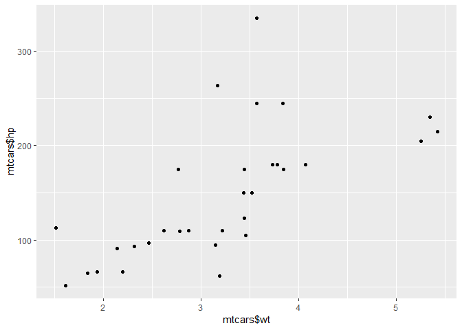

```r
# Load the ggplot2 package
library(ggplot2)

# Retry the qplot() function
qplot(mtcars$wt, mtcars$hp)
```

```r
# Check out the currently attached packages again
search()
```

```
##  [1] ".GlobalEnv"         "package:ggplot2"    "package:xml2"
##  [4] "package:kableExtra" "package:knitr"      "package:stats"
##  [7] "package:graphics"   "package:grDevices"  "package:utils"
## [10] "package:datasets"   "package:methods"    "Autoloads"
## [13] "package:base"
```

#### Different ways to load a package

The `library()` and `require()` functions are not very picky when it comes down to argument types: both `library(rjson)` and `library("rjson")` work perfectly fine for loading a package.

Have a look at some more code chunks that (attempt to) load one or more packages:

```r
# Chunk 1
library(data.table)
require(rjson)

# Chunk 2
library("data.table")
require(rjson)

# Chunk 3
library(data.table)
require(rjson, character.only = TRUE)

# Chunk 4
library(c("data.table", "rjson"))
```

Only chunk 1 and chunk 2 are correct. Can you figure out why the last two aren’t valid?